# Homework 6 – QTM 150

Minh-Thy Tyler

## Homework 6

**1** (2 pt). Load the packages `tidyverse`. Load the dataset `voteincome.csv` (check the class GitHub / Canvas). To load the dataset, use the function `read_csv`, from the `tidyverse` library.

```r
library('tidyverse')
getwd()
```

```
## [1] "/Users/minh-thytyler/Desktop/2021 freshman/QTM 150"
```

```r
vote <- read.csv('voteincome.csv')
# Your answers here
```

The dataset has the following informations:

- **VoteIncome**:

> Sample Turnout and Demographic Data from the 2000 Current Population Survey

> This data set contains turnout and demographic data from a sample of respondents to the 2000 Current Population Survey (CPS). The states represented are South Carolina and Arkansas. The data represent only a sample and results from this example should not be used in publication.

> Format A data frame containing 7 variables (“state”, “year”, “vote”, “income”, “education”, “age”, “female”) and 1500 observations.

> vote an integer vector taking on values “1” (Voted) and “0” (Did Not Vote)

> income an integer vector ranging from “4” (Less than $5000) to “17” (Greater than $75000) denoting family income. See the CPS codebook for more information on variable coding

> education an integer vector ranging from “1” (Less than High School Education) to “4” (More than a College Education). See the CPS codebook for more information on variable coding

> References https://www.census.gov/programs-surveys/cps.html

**2** (2 pt). Make a boxplot (or violin-plot) of income, segmented by education. What can you infer from this plot?

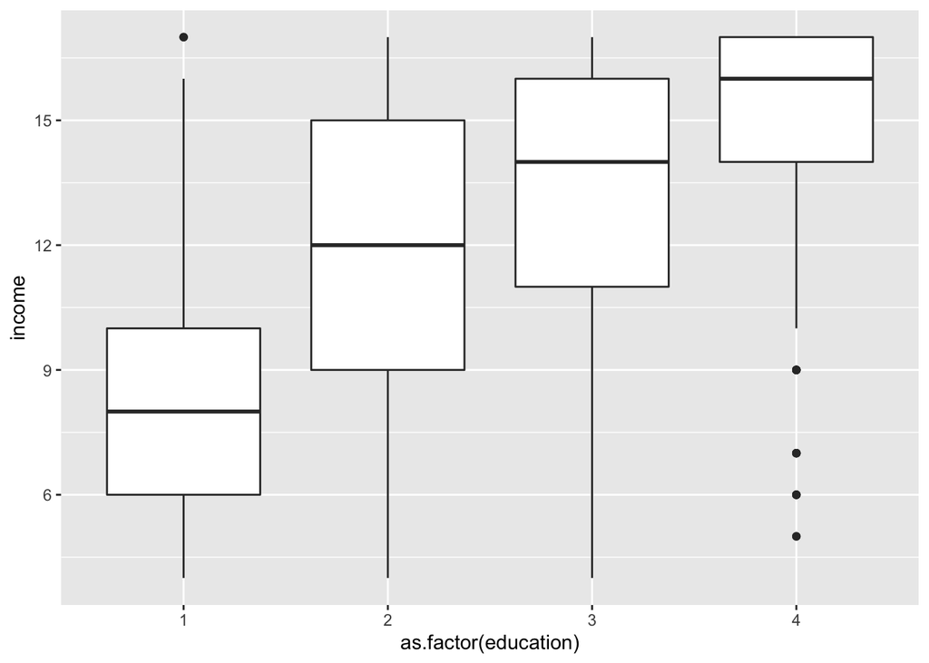

```r
vote  %>%ggplot() +geom_boxplot (mapping = aes(x = as.factor(education), y = income))
```

```r
# Your answers here
```

*From the boxplot, it seems to be that the higher education one has, the higher the median of income there is.*

**3** (2 pt). Are more educated people more likely to vote? Check that by making a mosaic-plot of `vote` against `education`.

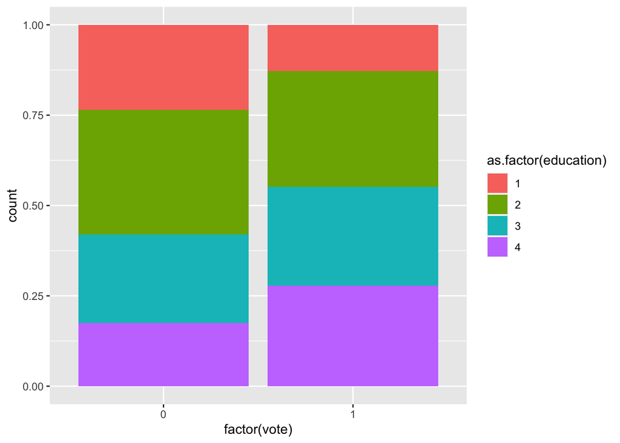

```r
ggplot(data = vote) +geom_bar(mapping = aes(x = factor(vote),fill = as.factor(education)),position = 'fill')
```

```r
# Your answers here
```

*More educated people are more likely to vote. Looking at the mosaic plot, (0 being people do not vote and 1 meaning people do vote) more educated people tended to vote more (4 and 3 are larger in 1 than 0) and more people with 1 and 2 education did not vote than did*

**4** (2 pt). Make a barplot of the variable `education`. Plot each bar using a different color.

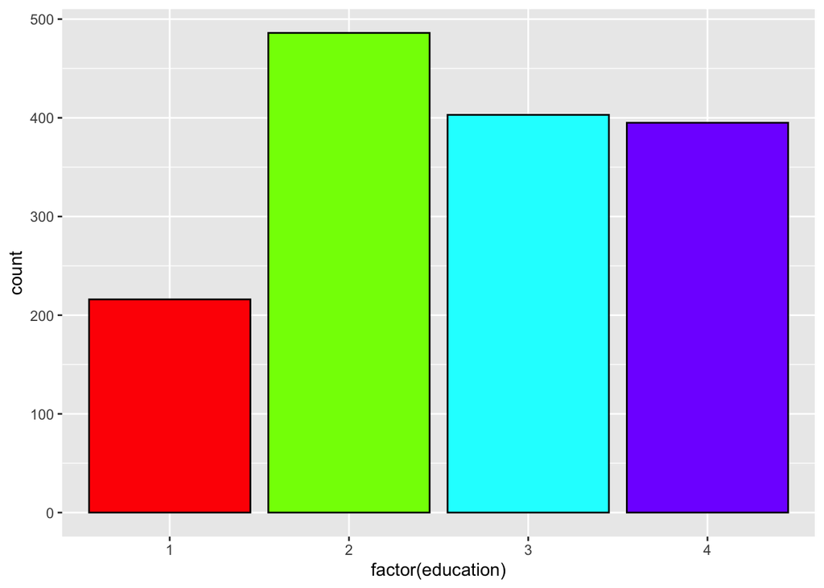

```r
ggplot(data = vote) + geom_bar(mapping = aes(x=factor(education)), fill =rainbow(4), color = 'black')
```

```r
# Your answers here
```

**5** (2 pt). Make a plot to answer the following question: is there a relation between age and income? (Hint: the plot is going to look ugly. Add a trend line to see the relationship.)

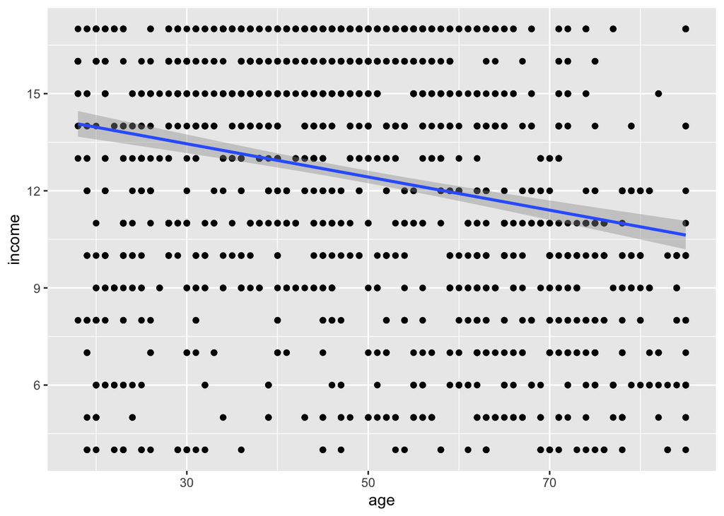

```r
ggplot(data = vote) + geom_point(mapping=aes(x=age, y=income))+geom_smooth(mapping=aes(x=age, y=income), method= 'lm')
```

```r
# Your answers here
```

*There seems to be a negative correlation between age in income. There is a downward trendline, and it it shows that the older you are, the lower your income is*